# FORD GoBike SYSTEM : INSIGHTS

## By Ahmad Ayantola

## Investigation Overview

> The goal of the investigation is to analyze the Ford gobike system and determine the category of people that uses the system more, the duration and distance of ride as well as the effect of gender on them

> These are the main insights:
> - Men are the majority users of the ford gobike system and most of them are young people
> - Gender is not a factor in determining duration and time of travel ( boxplots will be used instead of violin plot)

## Dataset Overview

> This data set includes information about individual rides made in a bike-sharing system covering the greater San Francisco Bay area. This dataset was gottrn from one of Udacity's curated datasets. It consists of 16 columns with 180k+ records. The Ford GoBike system dataset provides anonymized, timestamped data about the start and end station for a bike, the duration of the ride, the user type (subscriber or customer), some customer-reported attributes like birth year and gender (the gender here is divide into three categories: male, female, other), as well as the the start and end time for each ride.

## INSIGHTS

> There are three genders using the ford gobike system (male, female, other) and the men are the majority users of the system accounting for more than 130k members

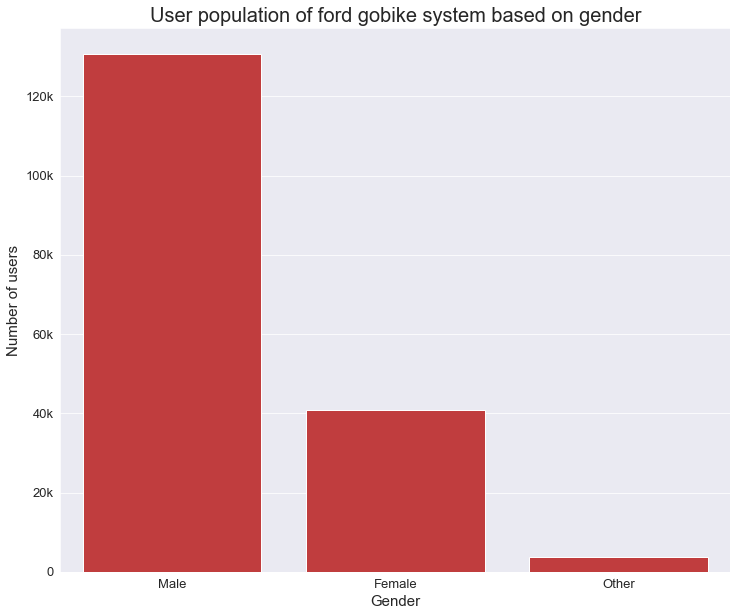

> There are about 175000+ users and majority of them are young people between the ages 16 - 39 year accounting for more than 90% of the total users. Only very few people in their 60s use the system

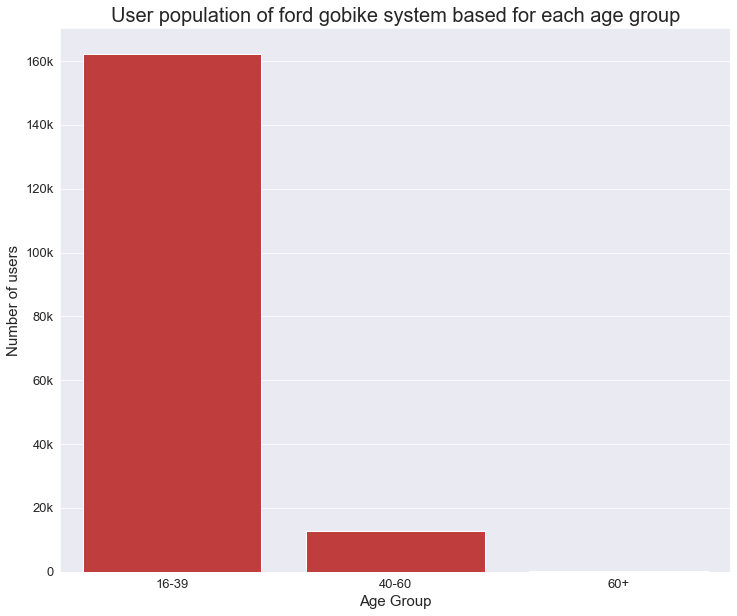

> Majority of the users ride for less than 20 minutes across all genders which is 75% of the population for each gender.

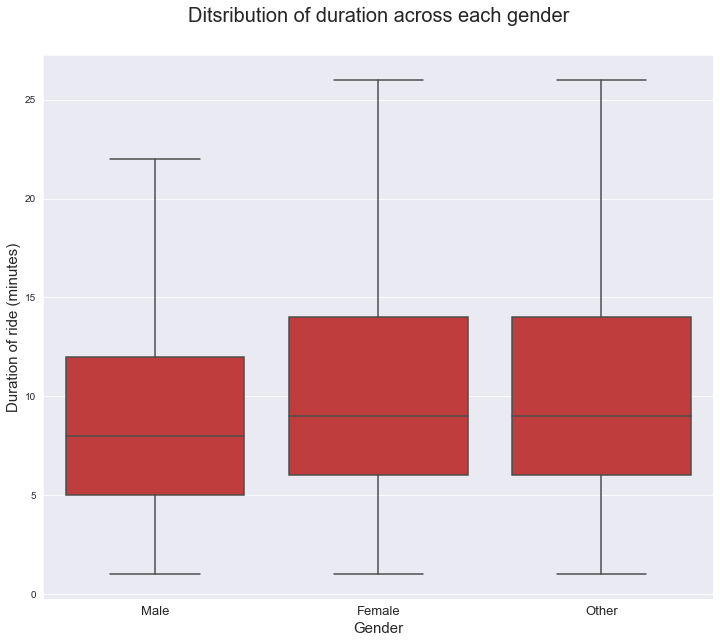

> Majority of the users ride for less than 4km across all gender and only a very few ride above 4km

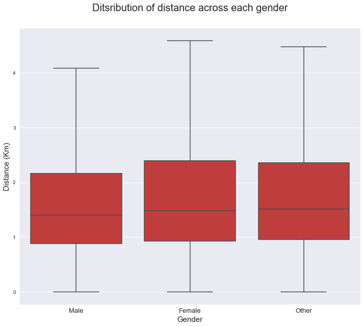

### RECOMMENDATION

> those in their 40s and above are really not using the ford bike system as compared with the younger generation, more awareness should be created as how the system works beacuse as they say "old people don't like what they don't trust"